# assignment3-JunHe

## Reinforcement Learning Programming - CSCN 8020 - Assignment 3

Jun He (8903073)

[figure not shown]

### Introduction

Individuals will work with the Pong environment and implement Deep Q-Learning. In this environment, if we got the right and left paddle's positions as the state, we would have continuous states that prevent the use of a tabular solutions, and thus the use of Q-Learning. To solve this problem, you will use a neural network to represent the function with Deep Q Networks and use the game frames as the observation. The way you interact with the environment will be very similar to the Ms. Pacman gym environment used in class.

### Action space

- 0: NOOP (No operation)
- 1: FIRE
- 2: Move right
- 3: Move left
- 4: Right Fire
- 5: Left Fire

### Observation Space

The environment has an observation space of size (210,160,3), which is an RGB image with values between 0 and 255.

Do not change the difficulty or mode, the default is set to 0 for both. Also, ensure you're using the PongDeterministic-v4 version of the environment, which has the reduced set of actions.

### Helper Utility

To assist in interacting with the environment, provided with a file (assignment3_utils.py) that has a few methods to allow pre-processing of the image: cropping, switching to grayscale, and downsizing.

### DQN [100]

#### Problem Statement

Implement the DQN algorithm on the Pong environment from OpenAI Gym. Train an agent to efficiently play the game (And win!). Use the following hyperparameters:

- Mini-batch size: 8
- Update rate of target network: 10 episodes
- Discount Factor γ: 0.95
- Exploration:
  - Exploration Factor Initial Value ε_init: 1.0
  - Exploration Decay Rate (δ): 0.995
  - Exploration minimum value ε_min: 0.05

Calculate the exploration rate using:

ε = ε * δ if ε ≥ ε_min = ε_min otherwise

## Tasks

```python
pip install gymnasium torch numpy matplotlib
```

[output not shown]

```python
import gymnasium as gym
import random
import numpy as np
import torch
import torch.nn as nn
import torch.optim as optim
import torch.nn.functional as F
import matplotlib.pyplot as plt
from collections import deque
```

```python
# Ensure required packages are installed
!pip install gymnasium[atari] ale-py
```

[output not shown]

```python
# import assignment3_utils as utils  # Helper functions for preprocessing
# Class for processing images from the Pong environment
class Preprocessor:
    """
    Preprocesses images from the Pong environment for input to DQN.
    """
    def __init__(self, image_shape=(84, 80)):
        self.image_shape = image_shape

    def img_crop(self, img):
        """ Crop unnecessary parts of the Pong environment image """
        return img[30:-12, :, :]

    def downsample(self, img):
        """ Downsample the image by a factor of 2 """
        return img[::2, ::2]

    def to_grayscale(self, img):
        """ Convert image to grayscale by averaging RGB channels """
        return np.mean(img, axis=2).astype(np.uint8)

    def normalize_grayscale(self, img):
        """ Normalize grayscale image from -1 to 1 """
        return (img - 128) / 128 - 1

    def process_frame(self, img):
        """ Apply all preprocessing steps to the input image """
        img = self.img_crop(img)
        img = self.downsample(img)
        img = self.to_grayscale(img)
        img = self.normalize_grayscale(img)
        return np.expand_dims(img.reshape(self.image_shape[0], self.image_shape[1], 1), axis=0)
```

```python
# Initialize Preprocessor
preprocessor = Preprocessor()
```

```python
class DQN(nn.Module):
    """
    Convolutional Neural Network for Deep Q-Learning.
    """
    def __init__(self, input_shape, num_actions):
        super(DQN, self).__init__()
        self.conv1 = nn.Conv2d(in_channels=4, out_channels=32, kernel_size=8, stride=4)
        self.conv2 = nn.Conv2d(in_channels=32, out_channels=64, kernel_size=4, stride=2)
        self.conv3 = nn.Conv2d(in_channels=64, out_channels=64, kernel_size=3, stride=1)

        # Calculate the flattened size after convolutions
        self._to_linear = self._get_conv_output((4, 84, 80))

        self.fc1 = nn.Linear(self._to_linear, 512)
        self.fc2 = nn.Linear(512, num_actions)

    def _get_conv_output(self, shape):
        """Compute the size of the tensor after the convolutional layers."""
        with torch.no_grad():
            x = torch.zeros(1, *shape)
            x = self.conv1(x)
            x = self.conv2(x)
            x = self.conv3(x)
            return int(np.prod(x.shape[1:]))

    def forward(self, x):
        x = x.squeeze(2)  # Ensure 4D shape (batch, 4, 84, 80)
        x = F.relu(self.conv1(x))
        x = F.relu(self.conv2(x))
        x = F.relu(self.conv3(x))
        x = x.view(x.size(0), -1)  # Flatten
        x = F.relu(self.fc1(x))
        return self.fc2(x)
```

### 1.2 Report the following metrics during training with the number of steps:

1. Score per episode
2. Average Cumulative reward of the last 5 episodes

```python
class TrainingLogger:
    """
    Logger for tracking training progress and metrics.
    """
    def __init__(self):
        self.scores = []
        self.avg_rewards = []

    def log(self, episode, score, avg_reward):
        self.scores.append(score)
        self.avg_rewards.append(avg_reward)
        print(f"Episode {episode}: Score = {score}, Avg Reward (last 5) = {avg_reward}")

    def plot_results(self):
        plt.figure(figsize=(10, 5))
        plt.plot(self.scores, label="Score per Episode")
        plt.plot(self.avg_rewards, label="Avg Reward (last 5)", linestyle="--")
        plt.xlabel("Episode")
        plt.ylabel("Score / Reward")
        plt.legend()
        plt.title("Training Progress")
        plt.show()
```

```python
# Initialize logger
logger = TrainingLogger()
```

```python
class ReplayBuffer:
    """
    Experience replay buffer for storing past experiences.
    """
    def __init__(self, capacity):
        self.buffer = deque(maxlen=capacity)

    def push(self, state, action, reward, next_state, done):
        self.buffer.append((state, action, reward, next_state, done))

    def sample(self, batch_size):
        return random.sample(self.buffer, batch_size)

    def __len__(self):
        return len(self.buffer)
```

### 1.1 Implement the DQN algorithm and train an agent on the Pong environment.

- Change the input size of the CNN and use all 4 images as an input instead of blending them

together.

- Note that if you apply the crop function in the utilities, you’ll need to change the input

state size to 84x80 instead of 105x80

```python
class DQNAgent:
    """
    DQN Agent with ε-greedy policy, experience replay, and target network.
    """
    def __init__(self, env, batch_size=8, gamma=0.95, lr=1e-4, epsilon=1.0, epsilon_min=0.05, epsilon_decay=0.995):
        self.env = env
        self.batch_size = batch_size
        self.gamma = gamma
        self.lr = lr
        self.epsilon = epsilon
        self.epsilon_min = epsilon_min
        self.epsilon_decay = epsilon_decay
        self.num_actions = env.action_space.n

        self.device = torch.device("cuda" if torch.cuda.is_available() else "cpu")

        # Initialize networks
        #  use all 4 images as an input instead of blending them  shape 84x80
        self.policy_net = DQN((4, 84, 80), self.num_actions).to(self.device)
        self.target_net = DQN((4, 84, 80), self.num_actions).to(self.device)
        self.target_net.load_state_dict(self.policy_net.state_dict())
        self.target_net.eval()

        self.optimizer = optim.Adam(self.policy_net.parameters(), lr=self.lr)
        self.memory = ReplayBuffer(10000)

    def select_action(self, state):
        if random.random() < self.epsilon:
            return self.env.action_space.sample()
        state = torch.FloatTensor(np.array(state)).unsqueeze(0).to(self.device)  # Ensure correct shape (1, 4, 84, 80)
        with torch.no_grad():
            return self.policy_net(state).argmax(dim=1).item()

    def train_step(self):
        if len(self.memory) < self.batch_size:
            return
        batch = self.memory.sample(self.batch_size)

        states, actions, rewards, next_states, dones = zip(*batch)
        states = torch.FloatTensor(np.stack(states)).to(self.device)  # Ensure 4D shape (batch, 4, 84, 80)
        states = states.squeeze(2)  # Remove incorrect singleton dimension
        actions = torch.LongTensor(actions).to(self.device)
        rewards = torch.FloatTensor(rewards).to(self.device)
        next_states = torch.FloatTensor(np.stack(next_states)).to(self.device)  # Ensure 4D shape
        next_states = next_states.squeeze(2)  # Remove incorrect singleton dimension
        dones = torch.FloatTensor(dones).to(self.device)

        q_values = self.policy_net(states).gather(1, actions.unsqueeze(1)).squeeze(1)
        next_q_values = self.target_net(next_states).max(1)[0]
        target_q_values = rewards + (1 - dones) * self.gamma * next_q_values

        loss = F.mse_loss(q_values, target_q_values)
        self.optimizer.zero_grad()
        loss.backward()
        self.optimizer.step()

    def update_target(self):
        self.target_net.load_state_dict(self.policy_net.state_dict())

    def decay_epsilon(self):
        self.epsilon = max(self.epsilon_min, self.epsilon * self.epsilon_decay)
```

```python
# Initialize Environment and Run Training
env = gym.make("PongDeterministic-v4")  # Updated for gymnasium compatibility
agent = DQNAgent(env)
```

```python
# Training Loop
def run_experiment(target_update_rate = 10):
    num_episodes = 200 #initial episodes

    for episode in range(num_episodes):
        state, _ = env.reset()
        state = preprocessor.process_frame(state)
        state = np.squeeze(state, axis=-1)  # Ensure correct shape (84, 80)
        state_stack = deque([state] * 4, maxlen=4)  # Stack last 4 frames
        total_reward = 0
        done = False

        while not done:
            stacked_state = np.stack(state_stack, axis=0)  # Ensure shape (4, 84, 80)
            action = agent.select_action(stacked_state)
            next_state, reward, done, truncated, _ = env.step(action)
            next_state = preprocessor.process_frame(next_state)
            next_state = np.squeeze(next_state, axis=-1)  # Ensure correct shape (84, 80)
            state_stack.append(next_state)
            agent.memory.push(np.stack(state_stack, axis=0), action, reward, np.stack(state_stack, axis=0), done)
            agent.train_step()
            total_reward += reward

        avg_reward = np.mean(logger.scores[-5:]) if len(logger.scores) >= 5 else total_reward
        logger.log(episode, total_reward, avg_reward)
        agent.decay_epsilon()
        if episode % target_update_rate == 0:
            agent.update_target()

    logger.plot_results()

    # Save Model
    torch.save(agent.policy_net.state_dict(), "dqn_pong_model.pth")  # Save model for later use
```

### 1.3 Plot the deliberate change to the following parameters SEPARATELY and plot a figure of the previous metrics for each change as follows:

- Plot figure with changing the mini-batch size: [8 (default), 16]
- Plot figure with changing the update rate of the target network to be every [3, 10 (default)]

episode

```
Batch_size=8, update rate of the target network=3
Episode 0: Score = -20.0, Avg Reward (last 5) = -20.0
Episode 1: Score = -18.0, Avg Reward (last 5) = -18.0
Episode 2: Score = -20.0, Avg Reward (last 5) = -20.0
Episode 3: Score = -21.0, Avg Reward (last 5) = -21.0
Episode 4: Score = -21.0, Avg Reward (last 5) = -21.0
Episode 5: Score = -19.0, Avg Reward (last 5) = -20.0
Episode 6: Score = -20.0, Avg Reward (last 5) = -19.8
Episode 7: Score = -21.0, Avg Reward (last 5) = -20.2
Episode 8: Score = -21.0, Avg Reward (last 5) = -20.4
Episode 9: Score = -21.0, Avg Reward (last 5) = -20.4
Episode 10: Score = -21.0, Avg Reward (last 5) = -20.4
Episode 11: Score = -21.0, Avg Reward (last 5) = -20.8
Episode 12: Score = -20.0, Avg Reward (last 5) = -21.0
Episode 13: Score = -21.0, Avg Reward (last 5) = -20.8
Episode 14: Score = -21.0, Avg Reward (last 5) = -20.8
Episode 15: Score = -21.0, Avg Reward (last 5) = -20.8
Episode 16: Score = -21.0, Avg Reward (last 5) = -20.8
Episode 17: Score = -21.0, Avg Reward (last 5) = -20.8
Episode 18: Score = -20.0, Avg Reward (last 5) = -21.0
Episode 19: Score = -21.0, Avg Reward (last 5) = -20.8
Episode 20: Score = -21.0, Avg Reward (last 5) = -20.8
Episode 21: Score = -21.0, Avg Reward (last 5) = -20.8
Episode 22: Score = -21.0, Avg Reward (last 5) = -20.8
Episode 23: Score = -21.0, Avg Reward (last 5) = -20.8
Episode 24: Score = -18.0, Avg Reward (last 5) = -21.0
Episode 25: Score = -19.0, Avg Reward (last 5) = -20.4
Episode 26: Score = -21.0, Avg Reward (last 5) = -20.0
Episode 27: Score = -21.0, Avg Reward (last 5) = -20.0
Episode 28: Score = -20.0, Avg Reward (last 5) = -20.0
Episode 29: Score = -21.0, Avg Reward (last 5) = -19.8
Episode 30: Score = -19.0, Avg Reward (last 5) = -20.4
Episode 31: Score = -21.0, Avg Reward (last 5) = -20.4
Episode 32: Score = -20.0, Avg Reward (last 5) = -20.4
Episode 33: Score = -21.0, Avg Reward (last 5) = -20.2
Episode 34: Score = -20.0, Avg Reward (last 5) = -20.4
Episode 35: Score = -20.0, Avg Reward (last 5) = -20.2
Episode 36: Score = -21.0, Avg Reward (last 5) = -20.4
Episode 37: Score = -20.0, Avg Reward (last 5) = -20.4
Episode 38: Score = -20.0, Avg Reward (last 5) = -20.4
```

[output cut: 146 more lines]

```
Episode 185: Score = -20.0, Avg Reward (last 5) = -20.8
Episode 186: Score = -21.0, Avg Reward (last 5) = -20.6
Episode 187: Score = -21.0, Avg Reward (last 5) = -20.6
Episode 188: Score = -21.0, Avg Reward (last 5) = -20.6
Episode 189: Score = -18.0, Avg Reward (last 5) = -20.8
Episode 190: Score = -20.0, Avg Reward (last 5) = -20.2
Episode 191: Score = -21.0, Avg Reward (last 5) = -20.2
Episode 192: Score = -21.0, Avg Reward (last 5) = -20.2
Episode 193: Score = -20.0, Avg Reward (last 5) = -20.2
Episode 194: Score = -21.0, Avg Reward (last 5) = -20.0
Episode 195: Score = -21.0, Avg Reward (last 5) = -20.6
Episode 196: Score = -21.0, Avg Reward (last 5) = -20.8
Episode 197: Score = -20.0, Avg Reward (last 5) = -20.8
Episode 198: Score = -21.0, Avg Reward (last 5) = -20.6
Episode 199: Score = -21.0, Avg Reward (last 5) = -20.8
```

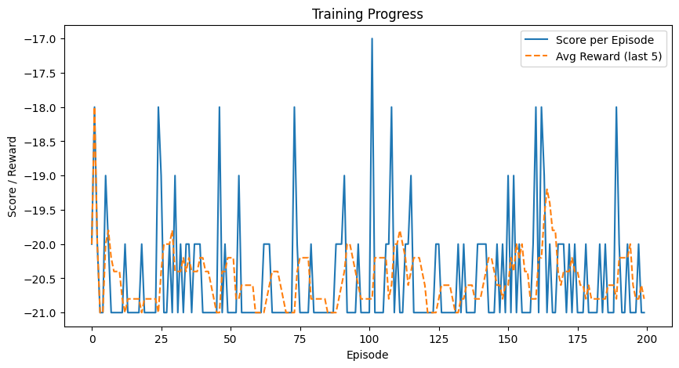

```
Batch_size=8, update rate of the target network=10
Episode 0: Score = -21.0, Avg Reward (last 5) = -20.8
Episode 1: Score = -20.0, Avg Reward (last 5) = -20.8
Episode 2: Score = -21.0, Avg Reward (last 5) = -20.6
Episode 3: Score = -21.0, Avg Reward (last 5) = -20.8
Episode 4: Score = -20.0, Avg Reward (last 5) = -20.8
Episode 5: Score = -21.0, Avg Reward (last 5) = -20.6
Episode 6: Score = -21.0, Avg Reward (last 5) = -20.6
Episode 7: Score = -20.0, Avg Reward (last 5) = -20.8
Episode 8: Score = -18.0, Avg Reward (last 5) = -20.6
Episode 9: Score = -20.0, Avg Reward (last 5) = -20.0
Episode 10: Score = -20.0, Avg Reward (last 5) = -20.0
Episode 11: Score = -20.0, Avg Reward (last 5) = -19.8
Episode 12: Score = -21.0, Avg Reward (last 5) = -19.6
Episode 13: Score = -20.0, Avg Reward (last 5) = -19.8
Episode 14: Score = -21.0, Avg Reward (last 5) = -20.2
Episode 15: Score = -20.0, Avg Reward (last 5) = -20.4
Episode 16: Score = -21.0, Avg Reward (last 5) = -20.4
Episode 17: Score = -21.0, Avg Reward (last 5) = -20.6
Episode 18: Score = -21.0, Avg Reward (last 5) = -20.6
Episode 19: Score = -21.0, Avg Reward (last 5) = -20.8
Episode 20: Score = -21.0, Avg Reward (last 5) = -20.8
Episode 21: Score = -21.0, Avg Reward (last 5) = -21.0
Episode 22: Score = -21.0, Avg Reward (last 5) = -21.0
Episode 23: Score = -21.0, Avg Reward (last 5) = -21.0
Episode 24: Score = -20.0, Avg Reward (last 5) = -21.0
Episode 25: Score = -20.0, Avg Reward (last 5) = -20.8
Episode 26: Score = -21.0, Avg Reward (last 5) = -20.6
Episode 27: Score = -20.0, Avg Reward (last 5) = -20.6
Episode 28: Score = -21.0, Avg Reward (last 5) = -20.4
Episode 29: Score = -19.0, Avg Reward (last 5) = -20.4
Episode 30: Score = -21.0, Avg Reward (last 5) = -20.2
Episode 31: Score = -21.0, Avg Reward (last 5) = -20.4
Episode 32: Score = -21.0, Avg Reward (last 5) = -20.4
Episode 33: Score = -20.0, Avg Reward (last 5) = -20.6
Episode 34: Score = -21.0, Avg Reward (last 5) = -20.4
Episode 35: Score = -21.0, Avg Reward (last 5) = -20.8
Episode 36: Score = -21.0, Avg Reward (last 5) = -20.8
Episode 37: Score = -20.0, Avg Reward (last 5) = -20.8
Episode 38: Score = -21.0, Avg Reward (last 5) = -20.6
```

[output cut: 146 more lines]

```
Episode 185: Score = -21.0, Avg Reward (last 5) = -20.2
Episode 186: Score = -21.0, Avg Reward (last 5) = -20.4
Episode 187: Score = -21.0, Avg Reward (last 5) = -20.4
Episode 188: Score = -21.0, Avg Reward (last 5) = -20.6
Episode 189: Score = -21.0, Avg Reward (last 5) = -21.0
Episode 190: Score = -20.0, Avg Reward (last 5) = -21.0
Episode 191: Score = -21.0, Avg Reward (last 5) = -20.8
Episode 192: Score = -21.0, Avg Reward (last 5) = -20.8
Episode 193: Score = -20.0, Avg Reward (last 5) = -20.8
Episode 194: Score = -21.0, Avg Reward (last 5) = -20.6
Episode 195: Score = -21.0, Avg Reward (last 5) = -20.6
Episode 196: Score = -21.0, Avg Reward (last 5) = -20.8
Episode 197: Score = -20.0, Avg Reward (last 5) = -20.8
Episode 198: Score = -19.0, Avg Reward (last 5) = -20.6
Episode 199: Score = -21.0, Avg Reward (last 5) = -20.4
```

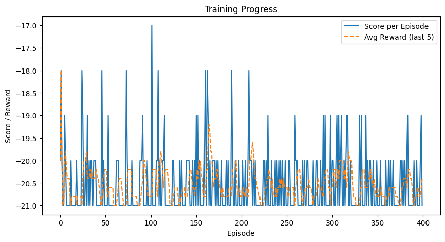

[output not shown]

[output cut: 146 more lines]

```
Episode 185: Score = -20.0, Avg Reward (last 5) = -20.8
Episode 186: Score = -21.0, Avg Reward (last 5) = -20.8
Episode 187: Score = -21.0, Avg Reward (last 5) = -20.8
Episode 188: Score = -21.0, Avg Reward (last 5) = -20.8
Episode 189: Score = -20.0, Avg Reward (last 5) = -20.8
Episode 190: Score = -19.0, Avg Reward (last 5) = -20.6
Episode 191: Score = -20.0, Avg Reward (last 5) = -20.4
Episode 192: Score = -21.0, Avg Reward (last 5) = -20.2
Episode 193: Score = -21.0, Avg Reward (last 5) = -20.2
Episode 194: Score = -21.0, Avg Reward (last 5) = -20.2
Episode 195: Score = -21.0, Avg Reward (last 5) = -20.4
Episode 196: Score = -21.0, Avg Reward (last 5) = -20.8
Episode 197: Score = -21.0, Avg Reward (last 5) = -21.0
Episode 198: Score = -21.0, Avg Reward (last 5) = -21.0
Episode 199: Score = -20.0, Avg Reward (last 5) = -21.0
```

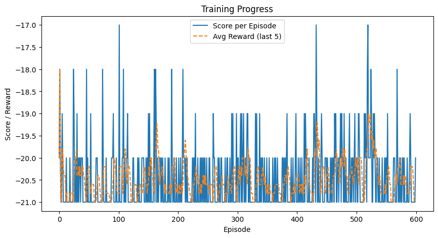

[output not shown]

[output cut: 51 more lines]

```
Episode 90: Score = -20.0, Avg Reward (last 5) = -20.6
Episode 91: Score = -21.0, Avg Reward (last 5) = -20.4
Episode 92: Score = -21.0, Avg Reward (last 5) = -20.8
Episode 93: Score = -21.0, Avg Reward (last 5) = -20.8
Episode 94: Score = -21.0, Avg Reward (last 5) = -20.8
Episode 95: Score = -21.0, Avg Reward (last 5) = -20.8
Episode 96: Score = -21.0, Avg Reward (last 5) = -21.0
Episode 97: Score = -21.0, Avg Reward (last 5) = -21.0
Episode 98: Score = -19.0, Avg Reward (last 5) = -21.0
Episode 99: Score = -21.0, Avg Reward (last 5) = -20.6
Episode 100: Score = -20.0, Avg Reward (last 5) = -20.6
Episode 101: Score = -21.0, Avg Reward (last 5) = -20.4
Episode 102: Score = -21.0, Avg Reward (last 5) = -20.4
Episode 103: Score = -21.0, Avg Reward (last 5) = -20.4
Episode 104: Score = -21.0, Avg Reward (last 5) = -20.8
```

```python
# Run experiments with different hyperparameters
batch_sizes = [8, 16]
update_frequencies = [3, 10]


for b in batch_sizes:
    agent = DQNAgent(env)
    for u in update_frequencies:
        print(f"Batch_size={b}, update rate of the target network={u}")
        run_experiment(u)
```

[output not shown]